# Análisis Estadístico con R - Parte I

## Técnicas de Conteo

Para calcular las probabilidades de varios eventos es necesario contar el número de resultados posibles de un experimento, o contal el número de resultados favorables en un evento dado. el proceso de conteo puede simplificarse mediante el empleo de dos técnicas de conteo denominadas Permutaciones y combinaciones.

**Regla de la Multiplicación**

$$\prod_{i=1}^k n_i$$

**Regla de la Adición**

$$\sum_{i=1}^k n_i$$

**Muestreo con reemplazo**: es el procedimiento de observar una unidad dentro de una población y retornarla al mismo conjunto. Entonces para $m$ muestras de $n$ objetos existen $n^m$ opciones de seleccionar una muestra.

**Muestreo sin reemplazo**: es el procedimiento de observar una unidad dentro de una población y extraerla del conjunto. Para seleccionar una muestra, es preciso preguntar ¿importa el orden?.

### Permutaciones

Se quiere seleccionar $r$ elementos de un conjunto de $n$ objetos, cuando importa el orden de selección.

$$n(n-1)(n-2)...(n-r+1)=\cfrac{n!}{(n-r)!}=P_{n}^{r}$$

Se tiene $n$ objetos, $n_1$ de tipo 1, $n_2$ de tipo 2, …, $n_r$ de tipo $r$, talque $\sum_{i=1}^r=n$, entonces las formas de seleccionar los objetos en grupos es:

$$P_{n}^{n_1 n_2 ... n_r}=\cfrac{n!}{n_1!n_2!...n_r!}$$

### Combinatorias

Se quiere seleccionar $r$ elementos de $n$ objetos donde no importa el orden.

$$C_n^r={n\choose_r}=\cfrac{n!}{r!(n-r)!}$$
**Teorema: Coeficiente Binomial**
$$(x+y)^n=\sum_{r=0}^n={n\choose_r}x^r y^{n-r}$$

Si se consideran repeticiones en este esquema, entonces:

$$CR_n^r={n+r-1\choose_r}=\cfrac{(n+r-1)!}{r!(n-1)!}$$

> En una bodega hay 5 tipos diferentes de botellas, ¿cuántas formas existen de elegir 4 botellas?
> $$CR_5^4={5+4-1\choose_4}=\cfrac{(5+4-1)!}{4!(5-1)!}=\cfrac{8!}{4!4!}=70$$

**Triángulo de Pascal**

$${n+1\choose_k}={n\choose_k}+{n\choose_k-1}$$

### Factoriales Generalizados

**Función Gamma**

$$\Gamma(n)=\int_0^\infty x^{n-1}e^{-x}dx$$

Propiedades:

1. Si $n \in \mathbb{Z}$, entonces $\Gamma(n)=(n-1)!$
2. Si $n>1$, entonces $\Gamma(n+1)=n\Gamma(n)=n!$
3. $\Gamma(1/2)=\pi$

**Función Beta**

$$Beta(x,y)=\cfrac{\Gamma(x)\Gamma(y)}{\Gamma(x+y)}$$

## Probabilidad

Los posibles resultados de un experimento son llamados eventos simples. Un experimento se dice “*aleatorio*” si proporciona diferentes resultados, aún cuando se realiza en las mismas condiciones.

El conjunto de todos los posibles resultados de un experimento es llamado **Espacio Muestral** y se denota como $\Omega$.

> Evento Discreto
> Se lanza una moneada no cargada, e identifica los resultados como “cara” y “sello”, entonces:
> $$\Omega=\{s,c\}$$

> Evento Continuo
> Se selecciona una bombilla y se registra su duración en horas, entonces:
> $$\Omega=[0,\infty)$$

Un *evento* es un subconjunto del espacio muestral $\Omega$, se dice que un evento $A$ ocurre si el resultado del experimento aleatorio pertenece a $A$

**Subconjunto**: Sean dos eventos $A$ y $B$. Si los elementos de un evento están contenidos en el otro, se llama subconjunto. $A \subset B$: *$A$ está contenido en $B$*, o $B \subset A$: *$B$ contiene $A$*.

**Conjuntos Equivalentes**: Si $A \subset B$ y $B \subset A$ entonces $A=B$.

**Conjunto Vacío**: Si $A$ no contienen elementos se llama vacío o nulo y se denota como $\emptyset$.

**Complemento**: El complemento de un evento $A$ respecto al espacio $\Omega$, son los elementos que están en $\Omega$ pero no en $A$, se denota como $\bar{A}$, $A^c$, $A^{\prime}$ o $\Omega - A$.

**Intersección**: Sean dos eventos $(A\wedge B) \in \Omega$, cuando todos los elementos están contenidos en $A$ y $B$ se le llama intersección de eventos $A \cap B$.

**Unión**: Sean dos eventos $(A\wedge B) \in \Omega$, cuando todos los elementos están contenidos en $A$ o $B$ o en ambos, se le llama unión de eventos. $A \cup B=A+B-A\cap B$

**Diferencia de Conjuntos**: Sean dos eventos $(A\wedge B) \in \Omega$, todos los elementos de $A$ que no se encuentran en $B$ determina la diferencia de conjutos $A-B$.

**Teoremas**

1. Ley conmutativa: $A \cup B=B\cup A$, $A \cap B = B \cap A$.
2. Ley asociativa: $A \cup (B \cup C)=(A \cup B) \cup C$, $A \cap (B \cap C)=(A \cap B) \cap C$.
3. Ley distributiva: $A \cap (B \cup C)=(A \cap B) \cup (A \cap C)$, $A \cup (B \cap C)=(A \cup B) \cap (A \cup C)$.
4. $\overline{(\bar{A})}=(A^\prime)^\prime=A$.
5. $A \Omega= A$, $A \cup \Omega = \Omega$, $A\emptyset=\emptyset$, $A \cup \emptyset=A$.
6. $A\bar{A}=\emptyset$, $A \cup \bar A=\Omega$, $A \cap A=A$, $A \cup A=A$.
7. $\overline{A\cup B}=\bar A \cap \bar B$, $\overline{A\cap B}=\bar A \cup \bar B$
8. $A-B=A\bar B$.
9. Ley de Morgan.
   - $\overline{\bigcup_{\lambda \in \Lambda}A_\lambda}=\bigcap_{\lambda\in\Lambda}\bar{A_\lambda}$.
   - $\overline{\bigcap_{\lambda \in \Lambda}A_\lambda}=\bigcup_{\lambda\in\Lambda}\bar{A_\lambda}$.
10. Si $(A\wedge B) \in \Omega$ entonces $A=AB \cup A\bar B$ y $AB \cap A\bar B=\emptyset$.
11. Si $A \subset B$ entonces $AB=A$ y $A\cup B=B$.

> Disyunción o Eventos Mutuamente Excluyentes  
> Sean $(A\wedge B) \in \Omega$, los eventos son disjuntos si $A \cap B=\emptyset$. En general una colección de eventos $A_1, A_2,...$ son mutuamente excluyentes si $A_i \cap A_j = \emptyset, \: \forall i \neq j$.

### Probabilidad *a priori*

Sea $A \in \Omega$ la probabilidad de ocurrencia del evento $A$ se define como:

$$P(A)=\cfrac{\text{# Casos favorables}}{\text{# Casos posibles}}$$

> Don Ramiro todos los días juega chance, apuesta los número 8845, 1254 y 6743. Como hoy es Martes, él sabe que la semana pasada el número gandor fue 9654. ¿Cuál es la probabilidad de ganar el chance con sus números? Como “ya cayó” el 9654 ¿justifica no jugarlo?

**Axiomas**

1. Sea $A \in \Omega$ entonces $P(A) \ge 0$
2. $P(\Omega)=1$.
3. Sean $(A\wedge B) \in \Omega$ eventos mutuamente excluyentes, entonces $P(A \cup B)=P(A)+P(B)$.
4. Si $\Omega$ está compuesto de infinitos conjuntos o eventos.
   - Si $A_1 \supset A_2 \supset A_3 \supset ...$ y $\bigcap_{n=1}^{\infty} A_n =\emptyset$ entonces $\text{lim}_{n \to \infty} P(A_n)=0$.
   - Sean $A_1, A_2, A_3,... \in \Omega$ si $A_i \cap A_j = \emptyset, \: \forall i\neq j$ entonces $P(\bigcup_{i=1}^{\infty}A_i)=\sum_{i=1}^{\infty}P(A_i)$.

**Propiedades**

1. $P(A^\prime)=1-P(A)$
2. $P(\emptyset)=0$
3. Si $A \subset B \Rightarrow P(A) \le P(B)$
4. Para cualquier evento $A$, $P(A)\le 1$
5. $P(A\cup B)=P(A)+P(B)-P(A \cap B)$

> Se lanza un dado. ¿Cual es la probabilidad de el resultado sea 2 o 5?
> A: Evento que el resultado es 2
> B: Evento que el resultado es 5
> $$P(A \cup B)=P(A)+P(B)=\cfrac{1}{6}+\cfrac{1}{6}=\cfrac{1}{3}$$

> En un lote de 50 bombillas hay 2 bombillas que presentan fallas. Un inspector examina 5 bombillas, las cuales fueron seleccionadas al azar y sin reemplazo. ¿Cuál es la probabilidad de que al menos 1 de las bombillas es defectuosa entre las 5 examinadas?
> A: Evento de tener todas las bombillas nuevas
> $$P(A^\prime)=1-P(A)$$
> $$P(A)=\cfrac{{48\choose 5} {2\choose 0}}{50 \choose 5}=0.8082$$
> $$P(A^\prime)=1-P(A)=1-0.8082=0.1918$$

> Una mano de cartas consiste en 5 cartas elegidas al azar y sin reemplazo de una baraja de 52 cartas. ¿Cuál es la probabilidad de que en la mano resulten 3 corazones y 2 picas?
> A: Evento de obtener 3 corazones y 2 picas
> $$P(A)=\cfrac{{13\choose 3} {13\choose 2}}{52 \choose 5}=0.0086$$

### Probabilidad Condicional

Algunas veces la ocurrencia de un envento $A$ puede afectar la ocurrencia posterior de otro evento $B$. Suponga un grupo de 20 artículos que contiene 10 defectuosos y 10 que no lo son. Una persona selecciona un artículo al azar y lo instala en un equipo

**A**: evento en que la selección del artículo resulte defectuoso
$$P(A)=\cfrac{10}{20}=0.5$$

Ahora bien, suponga que se selecciona otro artículo de los 19 restantes.

**B**: evento en que la selección del segundo artículo resulte defectuoso

| Si el primero es defectuoso | Si el primero no es defectuoso |
| --- | --- |
| $$P(B)=\cfrac{9}{19}$$ | $$P(B)=\cfrac{10}{19}$$ |

Sean $(A\wedge B) \in \Omega$, la probabilidad condicional $A$ dado $B$ denotado como $P(A|B)$ se define como:

$$P(A|B)=\frac{P(A \cap B)}{P(B)} \:\:\:\text{donde}\:P(B)>0$$
$$P(B|A)=\frac{P(A \cap B)}{P(A)} \:\:\:\text{donde}\:P(A)>0$$

> En un grupo de estudiante, el 40% de los alumnos juega al fútbol, el 30% al baloncesto y el 10% practica ambos deportes: Si juega fútbol, ¿cuál es la probabilidad de que juegue baloncesto?
> $$P(B|F)=\frac{P(B \cap F)}{P(F)}=\frac{0.1}{0.4}=0.25$$

**Regla Multiplicativa**
$$P(A \cap B)=P(A)P(B|A)=P(B)P(A|B)$$

**Teorema Probabilidad Total**
$$P(A)=\sum_{j=1}^{n}P(A \cap B_j)=\sum_{j=1}^{n}P(B_j)P(A|B_j)$$

### Teorema de Bayes

Sea $\{A_i\}_{i=1}^{n}$ un conjunto de $n$ eventos cada uno con probabilidad positiva, además son mutuamente excluyentes. Para cualquier evento $B \in \Omega$ con $P(B)>0$ se cumple:

$$P(A_j|B)=\frac{P(B|A_j)P(A_j)}{\sum_{i=1}^{n}P(A_j)P(B|A_j)}=\frac{\text{Regla Multiplicativa}}{\text{Probabilidad Total}}$$

> [Ejemplos Teorema de Bayes](https://brilliant.org/wiki/bayes-theorem/)

## Variables Aleatorias

En la mayoría de problemas a los que comúnmente nos enfrentamos, la descripción del conjunto de posibles resultados de un experimento aleatorio puede ser complicado y por lo tanto el cálculo de probabilidades también se dificulta.

Por ejemplo, si una persona es seleccionada de una población, diversas características pueden ser de interés y cada una aporta al entendimiento de un fenómeno en especial, como son, el tiempo que emplea en transportarse de su casa al lugar de trabajo, que tan lejos está de su casa el sitio donde trabaja, cuantos hijos tiene, cuantas horas duerme, cuantas personas conforman su grupo familiar, cuanto gana, cuanto gasta, cuanto paga por servicios, cuantas llamadas hace diariamente, etc.

Una **Variable Aleatoria** es una función definida en un espacio Muestral que asigna a cada resultado de un experimento aleatorio un valor real. Usualmente son denotadas con letras mayúsculas como (X , Y , Z , T, etc). Al conjunto de todos los posibles resultados de una variable aleatoria se le llamará Rango de la variable ($A_X$).

### Variables Aleatorias Discretas

- Un grupo de $n$ sujetos es sometido a cierto tratamiento y después de un tiempo se registra cuantos logran mejorar con dicho tratamiento. Sea X la variable aleatoria que cuenta cuántos sujetos mejoran con el tratamiento. Entonces el rango de $X$ será $A_X = {0, 1, 2,..., n}$.
- En una gran población se encuestan de manera aleatoria sujetos hasta encontrar el primero que responde afirmativamente a una pregunta de interés. Si $X$ es la variable aleatoria que cuenta el número de sujetos encuestados hasta encontrar el primero que responde afirmativamente, entonces el rango de $X$ está dado por $A_X = {1, 2, 3,...}$.

Este tipo de variables se traducen en funciones matemáticas o valores tabulados, y la probabilidad se calcula através de la *función de masa de probabilidad* (fmp).

### Variables Aleatorias Continuas

- De la producción diaria de jabones se escoge uno al azar y se mide su PH. Sea $X$: el pH del jabón. El rango de la variable aleatoria $X$ es cualquier valor entre 0 y 14. Así: $A_X = [0 , 14]$.
- El desgaste de una llanta en un período de un año es una variable aleatoria. Si $X$ es la variable aleatoria que representa el desgaste en décimas de milímetros, $A_X = (0 , a)$, donde $a$ representa la profundidad mínima de la llanta estando nueva.

Este tipo de variables se caracteriza porque el rango es un intervalo real, y su comportamiento está determinado por una función matemática y la probabilidad se calcula através de la *función de densidad de probabilidad* (pdf).

> Tanto las fmp como las pdf cumplen con los mismos Axiomas de probabilidad

El paquete `IPSUR` fue diseñado para la enseñanza de estadística y probabilidad por el profesor G. Jay Kerns. En el siguiente enlace se encuentra el curso completo usando `R`.

[IPSUR: Introduction to Probability and Statistics Using R](https://cran.r-project.org/web/packages/IPSUR/vignettes/IPSUR.pdf)

## Distribuciones de Probabilidad

Por muchos años los matemáticos y estadísticos han establecido funciones de probabilidad a diversos fenómenos de la naturaleza y la sociedad. No obstante, en algunos casos se observa que se cumplen ciertos patrones, por lo tanto, el comportamiento de un fenómeno se puede modelar con la misma función de probabilidad de otro fenómeno. En este sentido, se establecen las distribuciones de probabilidad como funciones definidas para entender el comportamiento de fenómenos que tienen un patrón identificable.

### Distribuciones de Probabilidad Discretas

#### Distribución Binomial

La distribución binomial es una distribución de probabilidad discreta que cuenta el número de éxitos en una secuencia de *n* ensayos de Bernoulli independientes entre sí, con una probabilidad fija *p* de ocurrencia del éxito entre los ensayos. Para $n = 1$, la binomial se convierte, de hecho, en una distribución de *Bernoulli*.

$$p(x)={n \choose x}p^x(1-p)^{n-x}\quad x = \{0, 1, 2, \dots , n\}$$

##### Distribución binomial con n=10, p=0.1

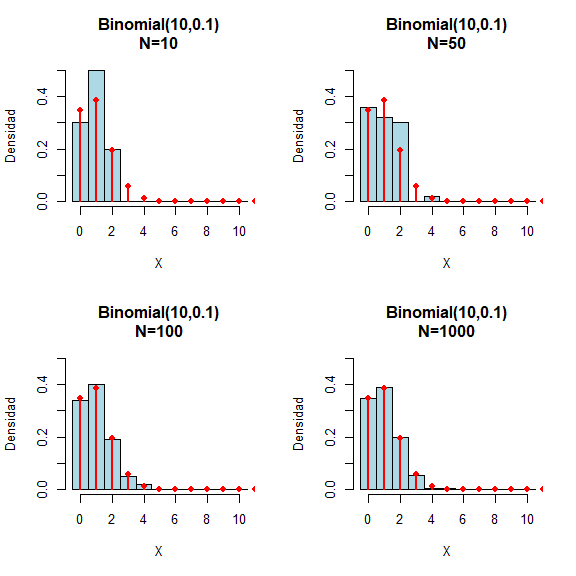

```r
# Semilla aleatoria
set.seed(999)

# Muestras binomiales de tamaño 10,50,100,1000
bin1<-list("N=10"=rbinom(10,10,0.1),"N=50"=rbinom(50,10,0.1),
        "N=100"=rbinom(100,10,0.1),"N=1000"=rbinom(1000,10,0.1))

# Clases del histogramas
b<-(-0.5:10.5)

# Múltiples gráficos
par(mfrow=c(2,2))
for(i in 1:4)
{
  hist(unlist(bin1[i]),freq=F,breaks=b,ylim=c(0,0.5),col='lightblue',xlab="X",
       ylab="Densidad",main=paste0("Binomial(10,0.1)\n",names(bin1)[i]))
  points(b+0.5,dbinom(b+0.5,10,0.1),col=2,pch=19)
  points(b+0.5,dbinom(b+0.5,10,0.1),col=2,type='h',lwd=2)
}
```

##### Distribución Binomial con n=10, p=0.5

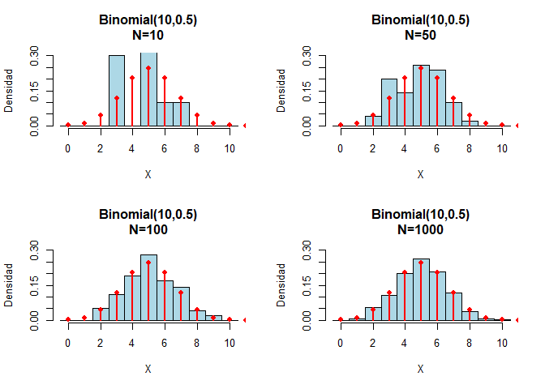

```r
# Semilla aleatoria
set.seed(999)
# Muestras binomiales de tamaño 10,50,100,1000
bin1<-list("N=10"=rbinom(10,10,0.5),"N=50"=rbinom(50,10,0.5),
        "N=100"=rbinom(100,10,0.5),"N=1000"=rbinom(1000,10,0.5))
# Clases del histogramas
b<-(-0.5:10.5)
# Múltiples gráficos
par(mfrow=c(2,2))
for(i in 1:4)
{
  hist(unlist(bin1[i]),freq=F,breaks=b,ylim=c(0,0.3),col='lightblue',xlab="X",
       ylab="Densidad",main=paste0("Binomial(10,0.5)\n",names(bin1)[i]))
  points(b+0.5,dbinom(b+0.5,10,0.5),col=2,pch=19)
  points(b+0.5,dbinom(b+0.5,10,0.5),col=2,type='h',lwd=2)
}
```

Se puede observar que para una distribución binomial con parámetro $p = 0.5$ la distribución teórica es simétrica. Por otra parte la distribución empírica se ajusta a la distribución teórica para tamaños de muestra muy grandes; contrario al caso anterior, el ajuste es más lento y se require tamaños de muestra $N \geq 1000$.

##### Distribución Binomial con n=10, p=0.9

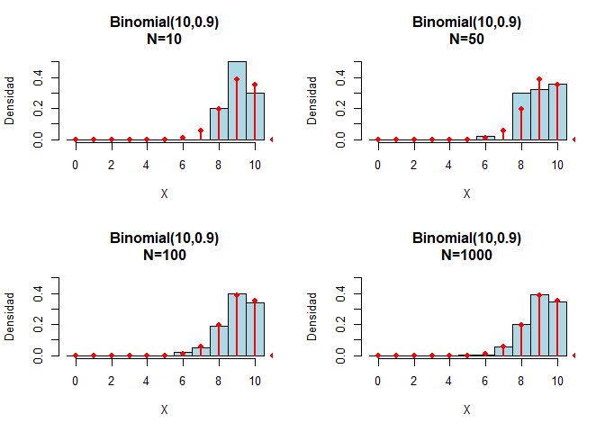

```r
# Semilla aleatoria
set.seed(999)
# Muestras binomiales de tamaño 10,50,100,1000
bin1<-list("N=10"=rbinom(10,10,0.9),"N=50"=rbinom(50,10,0.9),
        "N=100"=rbinom(100,10,0.9),"N=1000"=rbinom(1000,10,0.9))
# Clases del histogramas
b<-(-0.5:10.5)
# Múltiples gráficos
par(mfrow=c(2,2))
for(i in 1:4)
{
  hist(unlist(bin1[i]),freq=F,breaks=b,ylim=c(0,0.5),col='lightblue',xlab="X",
       ylab="Densidad",main=paste0("Binomial(10,0.9)\n",names(bin1)[i]))
  points(b+0.5,dbinom(b+0.5,10,0.9),col=2,pch=19)
  points(b+0.5,dbinom(b+0.5,10,0.9),col=2,type='h',lwd=2)
}
```

#### Distribución Geométrica

La variable aleatoria geométrica representa el número de fallas que ocurren antes de que se presente el primer éxito. La función de masa de probabilidad está dada por:

$$p(x) = (1 - p)^{x-1}p$$

##### Distribución Geometrica con p=0.3

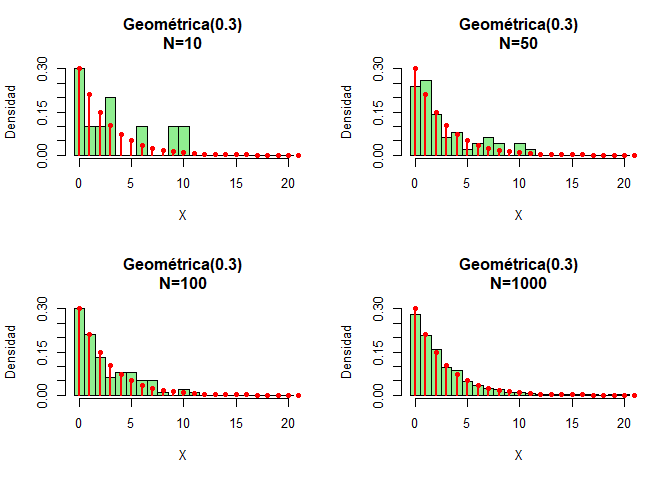

```r
# Semilla Aleatoria
set.seed(999)

# Muestras Geométricas de tamaño 10, 50, 100 y 1000
geo<-list("N=10"=rgeom(10,0.3),"N=50"=rgeom(50,0.3),
          "N=100"=rgeom(100,0.3),"N=1000"=rgeom(1000,0.3))

# Clases del histograma
b<-seq(-0.5,max(geo[[4]])+0.5)

# Múltiples Gráficos
par(mfrow=c(2,2))
for(i in 1:4)
{
  hist(unlist(geo[i]),freq=F,breaks=b,ylim=c(0,0.3),col='lightgreen',xlab="X",
       ylab="Densidad",main=paste0("Geométrica(0.3)\n",names(geo)[i]))
  points(b+0.5,dgeom(b+0.5,0.3),col=2,pch=19,cex=0.8)
  points(b+0.5,dgeom(b+0.5,0.3),col=2,type='h',lwd=2)
}
```

Se observa que la distribución teórica es asimétrica hacia la izquierda, pues cuenta el número de ensayos antes de obtener el primer éxito, por otra parte el número de ensayos aumenta cuando el parámetro *p* es pequeño, además la distribución empírica se ajusta a la teórica para tamaños de muestra grandes; en este caso la distribución con $p=0.3$, el ajuste de la distribución se alcanza para tamaños de muestra $N \geq 1000$

##### Distribución Geometrica con p=0.5

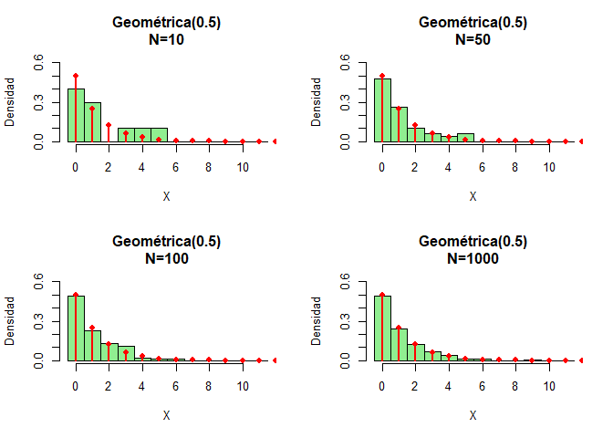

```r
# Semilla Aleatoria
set.seed(999)

# Muestras Geométricas de tamaño 10, 50, 100 y 1000
geo<-list("N=10"=rgeom(10,0.5),"N=50"=rgeom(50,0.5),
        "N=100"=rgeom(100,0.5),"N=1000"=rgeom(1000,0.5))

# Clases del histograma
b<-seq(-0.5,max(geo[[4]])+0.5)

# Múltiples Gráficos
par(mfrow=c(2,2))
for(i in 1:4)
{
  hist(unlist(geo[i]),freq=F,breaks=b,ylim=c(0,0.6),col='lightgreen',xlab="X",
       ylab="Densidad",main=paste0("Geométrica(0.5)\n",names(geo)[i]))
  points(b+0.5,dgeom(b+0.5,0.5),col=2,pch=19)
  points(b+0.5,dgeom(b+0.5,0.5),col=2,type='h',lwd=2)
}
```

Se observa que la distribución teórica es asimétrica hacia la izquierda, pues cuenta el número de ensayos antes de obtener el primer éxito, por otra parte el número de ensayos aumenta cuando el parámetro *p* es pequeño, además la distribución empírica se ajusta a la teórica para tamaños de muestra grandes; en este caso la distribución con $p=0.5$, el ajuste de la distribución se alcanza para tamaños de muestra $N \geq 100$

##### Distribución Geometrica con p=0.7

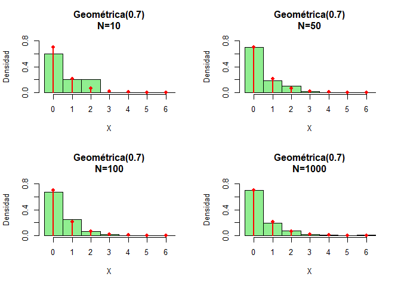

```r
# Semilla Aleatoria
set.seed(999)

# Muestras Geométricas de tamaño 10, 50, 100 y 1000
geo<-list("N=10"=rgeom(10,0.7),"N=50"=rgeom(50,0.7),
        "N=100"=rgeom(100,0.7),"N=1000"=rgeom(1000,0.7))

# Clases del histograma
b<-seq(-0.5,max(geo[[4]])+0.5)

# Múltiples Gráficos
par(mfrow=c(2,2))
for(i in 1:4)
{
  hist(unlist(geo[i]),freq=F,breaks=b,ylim=c(0,0.8),col='lightgreen',xlab="X",
       ylab="Densidad",main=paste0("Geométrica(0.7)\n",names(geo)[i]))
  points(b+0.5,dgeom(b+0.5,0.7),col=2,pch=19)
  points(b+0.5,dgeom(b+0.5,0.7),col=2,type='h',lwd=2)
}
```

Se observa que la distribución teórica es asimétrica hacia la izquierda, pues cuenta el número de ensayos antes de obtener el primer éxito, por otra parte el número de ensayos disminuye cuando el parámetro *p* es grande, además la distribución empírica se ajusta a la teórica para tamaños de muestra grandes; en este caso la distribución con $p=0.7$, el ajuste de la distribución se alcanza para tamaños de muestra $N \geq 50$

#### Distribución Binomial Negativa

Esta distribución puede considerarse como una extensión o ampliación de la distribución *geométrica*. La distribución binomial negativa es un modelo adecuado para tratar aquellos procesos en los que se repite un determinado ensayo o prueba hasta conseguir un número determinado de resultados favorables (por vez primera) .Es por tanto de gran utilidad para aquellos muestreos que procedan de esta manera. Si el número de resultados favorables buscados fuera 1 estaríamos en el caso de la distribución geométrica.

$$p(x)= {x-1 \choose x-k}p^k(1-p)^{x-k} = {x-1 \choose k-1}p^k(1-p)^{x-k}$$

##### Distribución Binomial Negativa con k=3 y p=0.3

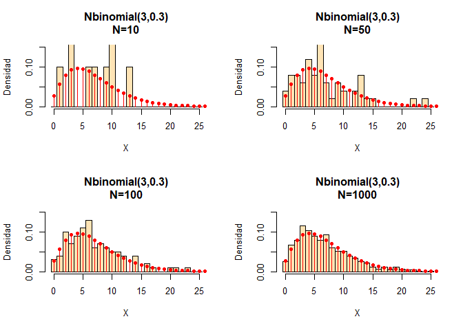

```r
# Semilla Aleatoria
set.seed(999)

# Muestras Geométricas de tamaño 10, 50, 100 y 1000
nbin<-list("N=10"=rnbinom(10,3,0.3),"N=50"=rnbinom(50,3,0.3),
        "N=100"=rnbinom(100,3,0.3),"N=1000"=rnbinom(1000,3,0.3))

# Clases del histograma
b<-seq(-0.5,max(nbin[[4]])+0.5)

# Múltiples Gráficos
par(mfrow=c(2,2))
for(i in 1:4)
{
  hist(unlist(nbin[i]),freq=F,breaks=b,ylim=c(0,0.15),col='moccasin',xlab="X",
       ylab="Densidad",main=paste0("Nbinomial(3,0.3)\n",names(nbin)[i]))
  points(b+0.5,dnbinom(b+0.5,3,0.3),col=2,pch=19,cex=0.8)
  points(b+0.5,dnbinom(b+0.5,3,0.3),col=2,type='h',lwd=1)
}
```

Se observa que la distribución empírica se ajusta a la teórica con tamaños de muestra grandes. En particular para un número de éxitos fijo $k=3$, se observa que la distribución es asimétrica hacia la izquierda y con $p=0.3$ la distribución empírica se ajusta con tamaños de muestra $N \geq 1000$. Por otra parte, a medida que aumenta el parámetro *p* el número de ensayos disminuyen y la densidad de probabilidad aumenta.

##### Distribución Binomial Negativa con k=3 y p=0.5

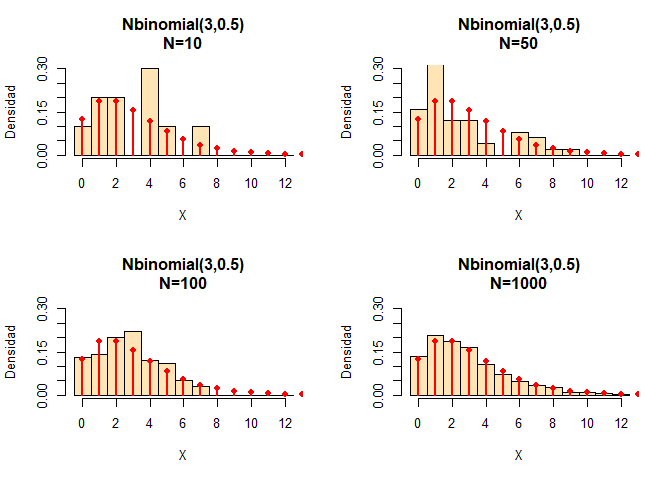

```r
# Semilla Aleatoria
set.seed(999)
# Muestras Geométricas de tamaño 10, 50, 100 y 1000
nbin<-list("N=10"=rnbinom(10,3,0.5),"N=50"=rnbinom(50,3,0.5),
        "N=100"=rnbinom(100,3,0.5),"N=1000"=rnbinom(1000,3,0.5))
# Clases del histograma
b<-seq(-0.5,max(nbin[[4]])+0.5)
# Múltiples Gráficos
par(mfrow=c(2,2))
for(i in 1:4)
{
  hist(unlist(nbin[i]),freq=F,breaks=b,ylim=c(0,0.3),col='moccasin',xlab="X",
       ylab="Densidad",main=paste0("Nbinomial(3,0.5)\n",names(nbin)[i]))
  points(b+0.5,dnbinom(b+0.5,3,0.5),col=2,pch=19)
  points(b+0.5,dnbinom(b+0.5,3,0.5),col=2,type='h',lwd=2)
}
```

Se observa que la distribución empírica se ajusta a la teórica con tamaños de muestra grandes. En particular para un número de éxitos fijo $k=3$, se observa que la distribución es asimétrica hacia la izquierda y con $p=0.5$ la distribución empírica se ajusta con tamaños de muestra $N \geq 1000$. Por otra parte, a medida que aumenta el parámetro *p* el número de ensayos disminuyen y la densidad de probabilidad aumenta.

##### Distribución Binomial Negativa con k=3 y p=0.7

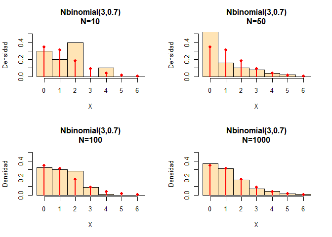

```r
# Semilla Aleatoria
set.seed(999)
# Muestras Geométricas de tamaño 10, 50, 100 y 1000
nbin<-list("N=10"=rnbinom(10,3,0.7),"N=50"=rnbinom(50,3,0.7),
        "N=100"=rnbinom(100,3,0.7),"N=1000"=rnbinom(1000,3,0.7))
# Clases del histograma
b<-seq(-0.5,max(nbin[[4]])+0.5)
# Múltiples Gráficos
par(mfrow=c(2,2))
for(i in 1:4)
{
  hist(unlist(nbin[i]),freq=F,breaks=b,ylim=c(0,0.5),col='moccasin',xlab="X",
       ylab="Densidad",main=paste0("Nbinomial(3,0.7)\n",names(nbin)[i]))
  points(b+0.5,dnbinom(b+0.5,3,0.7),col=2,pch=19)
  points(b+0.5,dnbinom(b+0.5,3,0.7),col=2,type='h',lwd=2)
}
```

Se observa que la distribución empírica se ajusta a la teórica con tamaños de muestra grandes. En particular para un número de éxitos fijo $k=3$, se observa que la distribución es asimétrica hacia la izquierda y con $p=0.7$ la distribución empírica se ajusta con tamaños de muestra $N \geq 1000$. Por otra parte, a medida que aumenta el parámetro *p* el número de ensayos disminuyen y la densidad de probabilidad aumenta.

##### Distribución Binomial Negativa con k=30 y p=[0.3,0.5,0.7]

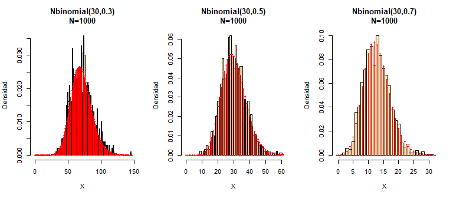

```r
# Semilla Aleatoria
set.seed(999)

# Muestras Geométricas de tamaño 1000
nbin<-list("N=1000"=rnbinom(1000,30,0.3),"N=1000"=rnbinom(1000,30,0.5),
        "N=1000"=rnbinom(1000,30,0.7))

# Clases del histograma
b<-list(seq(-0.5,max(nbin[[1]])+0.5),seq(-0.5,max(nbin[[2]])+0.5),
     seq(-0.5,max(nbin[[3]])+0.5))
p<-c(0.3,0.5,0.7)

# Múltiples Gráficos
par(mfrow=c(1,3))
for(i in 1:3)
{
  hist(unlist(nbin[i]),freq=F,breaks=b[[i]],col='moccasin',xlab="X",
       ylab="Densidad",main=paste0("Nbinomial(30,",p[i],")\n",names(nbin)[i]))
  points(b[[i]]+0.5,dnbinom(b[[i]]+0.5,30,p[i]),col=2,pch=19,cex=0.7)
  points(b[[i]]+0.5,dnbinom(b[[i]]+0.5,30,p[i]),col=2,type='h',lwd=1)
}
```

Se observa que la distribución empírica se ajusta a la teórica con tamaños de muestra grandes. Se puede observar que a medida que el parámetro *p* aumenta, disminuye el número de ensayos antes de obtener los *k* éxitos y aumenta la densidad de probabilidad; por otra parte cuando el parámetro *k* aumenta se observa la distribución tiende a ser simétrica.

#### Distribución Hipergeométrica

La distribución hipergeométrica es una distribución discreta que modela el número de eventos en una muestra de tamaño fijo cuando se conoce el número total de elementos en la población de la cual proviene la muestra. Las muestras no tienen reemplazo, por lo que cada elemento de la muestra es diferente. Cuando se elige un elemento de la población, no se puede volver a elegir. Por lo tanto, la probabilidad de que un elemento en particular sea seleccionado aumenta con cada ensayo, suponiendo que aún no ha sido seleccionado.

$$P(X=x)=\frac{{k \choose x}{{N-k \choose n-x}}}{{N \choose n}} \quad x=0,1,...,k$$

Donde $N$ es el tamaño de población, $n$ es el tamaño de la muestra extraída, $k$ es el número de elementos en la población original que pertenecen a la categoría deseada y $x$ es el número de elementos en la muestra que pertenecen a dicha categoría.

##### Distribución hipergeométrica $N=80$ $k=10$ $n=10$

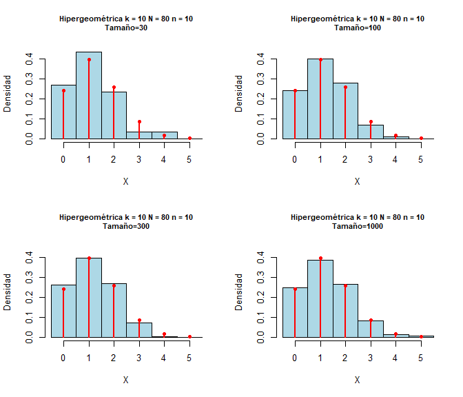

```r
# Semilla aleatoria
set.seed(999)

# Muestras Hipergeométricas de tamaño 30,100,300,1000
N<-80; k<-10; n<-10
hyp<-list("Tamaño=30"=rhyper(30,n,N-n,k),"Tamaño=100"=rhyper(100,n,N-n,k),
          "Tamaño=300"=rhyper(300,n,N-n,k),"Tamaño=1000"=rhyper(1000,n,N-n,k))

# Clases del histogramas
b<-seq(-0.5,max(hyp[[4]])+0.5)

# Múltiples gráficos
par(mfrow=c(2,2))
for(i in 1:4)
{
   hist(unlist(hyp[i]),freq=F,breaks=b,ylim=c(0,0.45),col='lightblue',xlab="X",
        main=paste0("Hipergeométrica k = ",k,' N = ',N,' n = ',n,'\n',names(hyp)[i]),
        cex.main=0.8,ylab="Densidad")
   points(b+0.5,dhyper(b+0.5,n,N-n,k),col=2,pch=19,cex=0.8)
   points(b+0.5,dhyper(b+0.5,n,N-n,k),col=2,type='h',lwd=2)
}
```

En el gráfico se ve que cuando el parámetro que denota el número de elementos de interés en la población original ($k$) es pequeño e igual a la muestra extraída ($n$), la distribución es asimétrica hacia la derecha, además a medida que el tamaño de muestra aumenta la distribución muestral se ajusta a la función de densidad con tamaños superiores a $100$.

##### Distribución hipergeométrica $N=60$ $k=10$ $n=25$

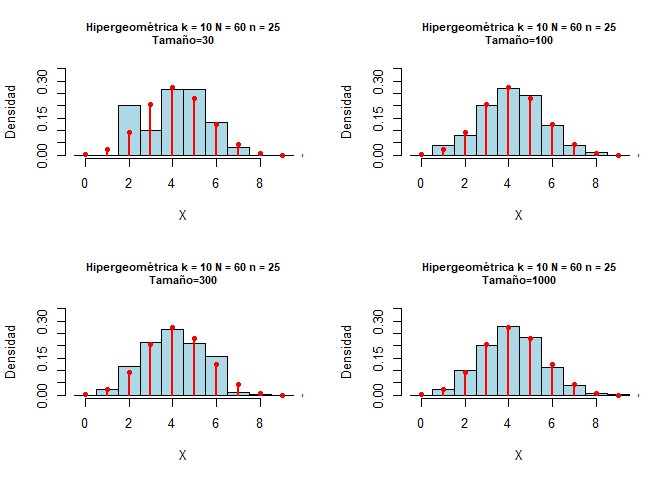

```r
# Semilla aleatoria
set.seed(999)
# Muestras Hipergeométricas de tamaño 30,100,300,1000
N<-60; k<-10; n<-25
hyp<-list("Tamaño=30"=rhyper(30,n,N-n,k),"Tamaño=100"=rhyper(100,n,N-n,k),
          "Tamaño=300"=rhyper(300,n,N-n,k),"Tamaño=1000"=rhyper(1000,n,N-n,k))
# Clases del histogramas
b<-seq(-0.5,max(hyp[[4]])+0.5)
# Múltiples gráficos
par(mfrow=c(2,2))
for(i in 1:4)
{
   hist(unlist(hyp[i]),freq=F,breaks=b,ylim=c(0,0.35),col='lightblue',xlab="X",
        main=paste0("Hipergeométrica k = ",k,' N = ',N,' n = ',n,'\n',names(hyp)[i]),
        cex.main=.8,ylab="Densidad")
   points(b+0.5,dhyper(b+0.5,n,N-n,k),col=2,pch=19,cex=0.8)
   points(b+0.5,dhyper(b+0.5,n,N-n,k),col=2,type='h',lwd=2)
}
```

##### Distribución hipergeométrica $N=60$ $k=35$ $n=25$

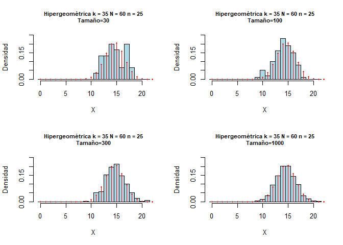

```r
# Semilla aleatoria
set.seed(999)
# Muestras Hipergeométricas de tamaño 30,100,300,1000
N<-60; k<-35; n<-25
hyp<-list("Tamaño=30"=rhyper(30,n,N-n,k),"Tamaño=100"=rhyper(100,n,N-n,k),
          "Tamaño=300"=rhyper(300,n,N-n,k),"Tamaño=1000"=rhyper(1000,n,N-n,k))
# Clases del histogramas
b<-seq(-0.5,max(hyp[[4]])+0.5)
# Múltiples gráficos
par(mfrow=c(2,2))
for(i in 1:4)
{
   hist(unlist(hyp[i]),freq=F,breaks=b,ylim=c(0,0.25),col='lightblue',xlab="X",
        main=paste0("Hipergeométrica k = ",k,' N = ',N,' n = ',n,'\n',names(hyp)[i]),
        cex.main=.8,ylab="Densidad")
   points(b+0.5,dhyper(b+0.5,n,N-n,k),col=2,pch=19,cex=0.5)
   points(b+0.5,dhyper(b+0.5,n,N-n,k),col=2,type='h',lwd=1)
}
```

#### Distribución Poisson

La distribución de *Poisson* es una distribución de probabilidad discreta que expresa, a partir de una frecuencia de ocurrencia media, la probabilidad de que ocurra un determinado número de eventos durante cierto período de tiempo. Concretamente, se especializa en la probabilidad de ocurrencia de sucesos con probabilidades muy pequeñas, o sucesos “raros”.

$$p(x;\lambda)=\frac{e^{-\lambda} \lambda^x}{x!}$$

##### Distribución Poission $\lambda=2$

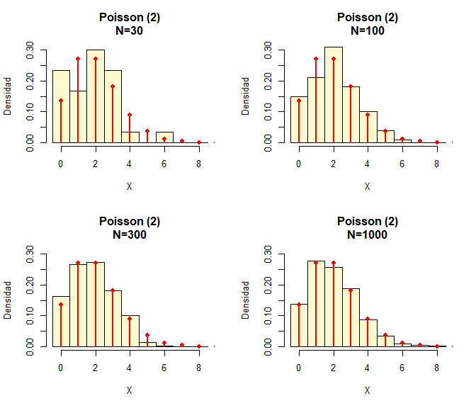

```r
# Semilla aleatoria
set.seed(999)

# Muestras poisson de tamaño 30,100,300,1000
pois<-list("N=30"=rpois(30,2),"N=100"=rpois(100,2),
        "N=300"=rpois(300,2),"N=1000"=rpois(1000,2))

# Clases del histogramas
b<-seq(-0.5,max(pois[[4]])+0.5)

# Múltiples gráficos
par(mfrow=c(2,2))
for(i in 1:4)
{
  hist(unlist(pois[i]),freq=F,breaks=b,ylim=c(0,0.3),col='lemonchiffon',xlab="X",
       ylab="Densidad",main=paste0("Poisson (2)\n",names(pois)[i]))
  points(b+0.5,dpois(b+0.5,2),col=2,pch=19)
  points(b+0.5,dpois(b+0.5,2),col=2,type='h',lwd=2)
}
```

En el gráfico se evidencia que la distribución *Poisson* es asimétrica hacia la izquerda para valores del parámetro $\lambda$ pequeños, además la distribución muestral se ajusta a la distribución teórica para tamaños de muestra $N \geq 300$.

##### Distribución Poission $\lambda=5$

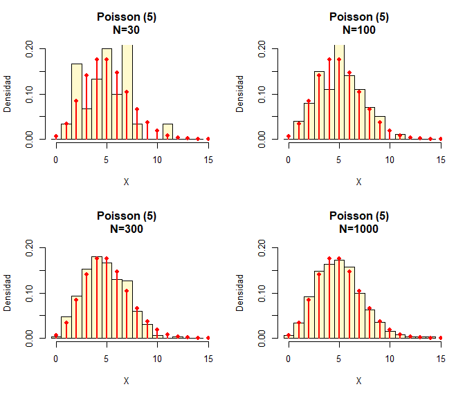

```r
# Semilla aleatoria
set.seed(999)
# Muestras poisson de tamaño 30,100,300,1000
pois<-list("N=30"=rpois(30,5),"N=100"=rpois(100,5),
        "N=300"=rpois(300,5),"N=1000"=rpois(1000,5))
# Clases del histogramas
b<-seq(-0.5,max(pois[[4]])+0.5)
# Múltiples gráficos
par(mfrow=c(2,2))
for(i in 1:4)
{
  hist(unlist(pois[i]),freq=F,breaks=b,ylim=c(0,0.20),col='lemonchiffon',xlab="X",
       ylab="Densidad",main=paste0("Poisson (5)\n",names(pois)[i]))
  points(b+0.5,dpois(b+0.5,5),col=2,pch=19)
  points(b+0.5,dpois(b+0.5,5),col=2,type='h',lwd=2)
}
```

##### Distribución Poission $\lambda=10$

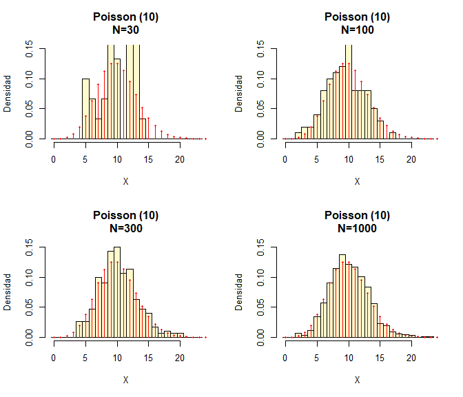

```r
# Semilla aleatoria
set.seed(999)
# Muestras poisson de tamaño 30,100,300,1000
pois<-list("N=30"=rpois(30,10),"N=100"=rpois(100,10),
        "N=300"=rpois(300,10),"N=1000"=rpois(1000,10))
# Clases del histogramas
b<-seq(-0.5,max(pois[[4]])+0.5)
# Múltiples gráficos
par(mfrow=c(2,2))
for(i in 1:4)
{
  hist(unlist(pois[i]),freq=F,breaks=b,ylim=c(0,0.15),col='lemonchiffon',xlab="X",
       ylab="Densidad",main=paste0("Poisson (10)\n",names(pois)[i]))
  points(b+0.5,dpois(b+0.5,10),col=2,pch=19,cex=0.5)
  points(b+0.5,dpois(b+0.5,10),col=2,type='h',lwd=1)
}
```

En el gráfico se evidencia que para valores grandes del parámetro $\lambda$ la distribución *Poisson* se hace simétrica presentando colas hacia ambos lados de la distribución, además la distribución muestral se ajusta a la distribución teórica para tamaños de muestra $N \geq 1000$.

#### Distribución Multinomial

```r
require(mvtnorm)
require(plot3D)
require(scatterplot3d)
```

La distribución multinomial es una generalización de la distribución binomial, la cual es la probabilidad de un número de éxitos en $N$ sucesos de *Bernoulli* independientes, con la misma probabilidad de éxito en cada suceso. En una distribución multinomial, el análogo a la distribución de Bernoulli es la distribución categórica, donde cada suceso concluye en únicamente un resultado de un número finito $K$ de los posibles, con probabilidades $p_1, \dots , p_k$ (tal que $p_i \geq 0$ para $i$ entre $1$ y $K$ y $\sum_{i=1}^k p_i = 1$) y con $n$ sucesos independientes.

Entonces sea la variable aleatoria $x_i$, que indica el número de veces que se ha dado el resultado $i$ sobre los n sucesos. El vector $x=(x_1,..., x_k)$ sigue una distribución multinomial con parámetros $n$ y $p$, donde $p=(p_1,...,p_k)$ la distribución multinomial es una generalización de la distribución binomial.

Para el caso de la *distribución trinomial*, la función de masa de probabilidad es:

$$p(x,y) = { \displaystyle {n! \over x!y!(n-x-y)!}p_1^{x}p_2^{y}(1-p_1-p_2)^{n-x-y}}, \quad \mbox{cuando } x+y \leq n$$

##### Distribución Trinomial $p_1=0.1$ $p_2=0.8$ $n=10$

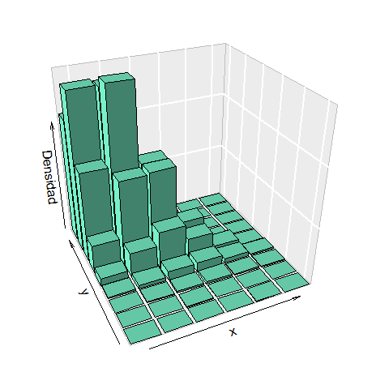

```r
# Semilla aleatoria
set.seed(999)

# Vector de probablidades
p<-c(0.1,0.8);p[3]<-1-sum(p)

# Número de ensayos
n<-10

# Muestra aleatoria multinomial de tamaño 1000
x<-t(rmultinom(10000,n,p))

# Matriz de densidades
d<-table(x[,1],x[,2])/100

# Histograma 3D
par(mar=c(2,2,2,2))
hist3D(z=d,col='aquamarine',border=1,phi = 30,theta=-25,d=2,bty='g',
       shade = .35, zlab = "Densidad",space = 0.1,cex.axis = 1e-9)
```

Por la ley de los grandes números se sabe que a medida que el tamaño de muestra aumenta la distribución empírica se ajusta a la distribución teórica. Para la distribución trinomial se evidencia que a medida que la probabilidad $p_2$ aumenta, la densidad se recarga en valores altos para el eje $y$ y en valores bajos para el eje $x$.

##### Distribución Trinomial $p_1=0.45$ $p_2=0.45$ $n=10$

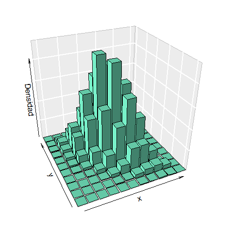

```r
# Semilla aleatoria
set.seed(999)

# Vector de probablidades
p<-c(0.45,0.45);p[3]<-1-sum(p)

# Número de ensayos
n<-10

# Muestra aleatoria multinomial de tamaño 1000
x<-t(rmultinom(10000,n,p))

# Matriz de densidades
d<-table(x[,1],x[,2])/100

# Histograma 3D
par(mar=c(2,2,2,2))
hist3D(z=d,col='aquamarine',border=1,phi = 30,theta=-25,d=2,bty='g',
       shade = .35, zlab = "Densidad",space = 0.1,cex.axis = 1e-9)
```

Por la ley de los grandes números se sabe que a medida que el tamaño de muestra aumenta la distribución empírica se ajusta a la distribución teórica. Para la distribución trinomial se evidencia que a medida que cuando la probabilidad $p_2=p_1$, la densidad se recarga en el centro del plano $(x,y)$.

##### Distribución Trinomial $p_1=0.8$ $p_2=0.1$ $n=10$

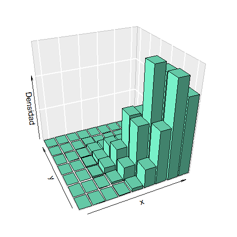

```r
# Semilla aleatoria
set.seed(999)

# Vector de probablidades
p<-c(0.8,0.1);p[3]<-1-sum(p)

# Número de ensayos
n<-10

# Muestra aleatoria multinomial de tamaño 1000
x<-t(rmultinom(10000,n,p))

# Matriz de densidades
d<-table(x[,1],x[,2])/100

# Histograma 3D
par(mar=c(2,2,2,2))
hist3D(z=d,col='aquamarine',border=1,phi = 30,theta=-25,d=2,bty='g',
       shade = .35, zlab = "Densidad",space = 0.1,cex.axis = 1e-9)
```

Por la ley de los grandes números se sabe que a medida que el tamaño de muestra aumenta la distribución empírica se ajusta a la distribución teórica. Para la distribución trinomial se evidencia que a medida que la probabilidad $p_1$ aumenta, la densidad se recarga en valores altos para el eje $x$ y en valores bajos para el eje $y$.

### Distribuciones de Probabilidad Continuas

#### Distribución Uniforme

Sea $X$ una v.a continua definida en el intervalo $(a,b)$ tal que $\forall_I \subset (a,b)$ la $P(X \in I)$ es proporcional a la longitud del intervalo.

Entonces se dice que $X$ tiene una distribución uniforme en el intervalo $(a,b)$. Para hallar la p.d.f. de X, como la probabilidad de que X pertenezca a cualquier subintervalo de $(a,b)$ es proporcional a su longitud, necesariamente la p.d.f. de X es una función constante;

$$f(x) =
\begin{cases}
k & ; \quad a<x<b\\
0 & ; \quad \text{en otro caso}\\
\end{cases}$$

$$P(X \in (a,b))=k(b-a)=1 \Rightarrow k=\cfrac{1}{b-a}$$

De esta manera, la p.d.f. de la variable aleatoria X es de la forma:

$$f(x) =
\begin{cases}
\cfrac{1}{b-a} & ; \quad a<x<b\\
\\
0 & ; \quad \text{en otro caso}\\
\end{cases}$$

$$F(x) =
\begin{cases}
0 & ; \quad x<a \\\\
\cfrac{x-a}{b-a} & ; \quad a \leq x \leq b \\\\
1 & ; \quad x>b\\
\end{cases}$$

Entonces $X \sim U(a,b)$, además:

$$M_X(t)=
\begin{cases}
\cfrac{\large e^{tb}-\large e^{ta}}{t(a-b)} \quad t \neq 0 \\ \\
\quad \quad 1 \quad \quad \quad t=0 \\
\end{cases}$$

Así, $E[X]=\cfrac{a+b}{2}$ y $\text{Var}[X]=\cfrac{(b-a)^2}{12}$

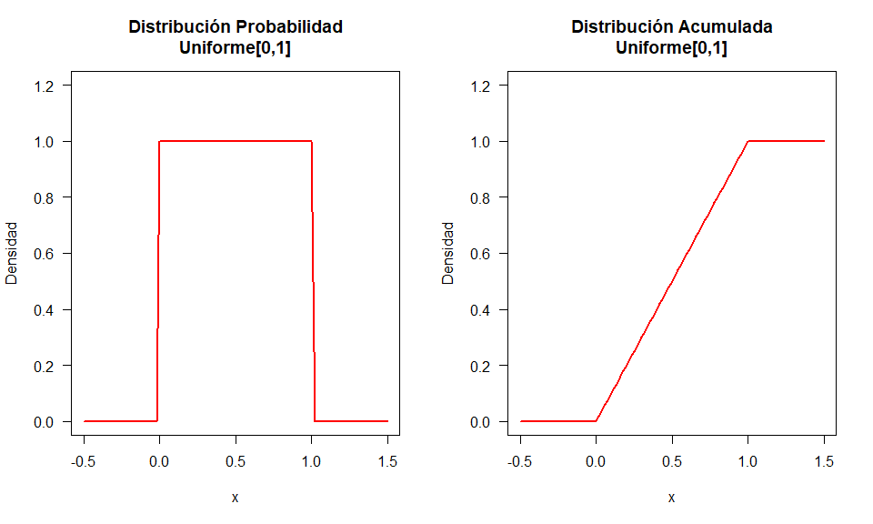

#### Distribución Normal

La *Distribución Normal* o *Gaussiana* es indudablemente la más importante y la de mayor uso de todas las distribuciones de probabilidad continua. Es la piedra angular en la aplicación de la inferencia estadística en el analisis de datos, puesto que las distribuciones de muchas *estadísticas muestrales* tienden hacia la distribución normal conforme crece el tamaño de muestra.

Algunos fenómenos presentan este tipo de distribución:

- Precipitación pluvial
- Temperaturas
- Mediciones en organismos vivos
- Calificaciones de pruebas de actitud
- Mediciones físicas en manufactura
- **Errores de instrumentación**

Debe tenerse mucho cuidado al suponer para una situación dada un modelo de probabilidad normal sin previa comprobación. si bien es cierto que esta distribución es la de mayor uso, también es de la que más se abusa. Quizás por la mala interpretación de la palabra “normal”, especialmente si se aplica su significado literal de “patrón o estándar aceptado”. Es posible que una distribución normal proporcione de manera razonable una aproximación alrededor de una media de una variable aleatoria; sin embargo, puede resultar que para valores extremos se encuentren en cualquier dirección.

La apariencia gráfica de la distribución normal es una curva simétrica con forma de campana, que se extiende sin límite tanto en dirección positiva como negativa.

##### Definición

Sea $X$ una v.a continua; se dice que $X$ tiene una distribución normal si su f.d.p es de la forma:

$$f(x)=\cfrac{1}{\sigma\sqrt{2 \pi}} \large e^{- \frac{(x-\mu)^2}{2\sigma^2}}; \quad \small -\infty< x <\infty; \quad \mu \in \mathit{R}; \quad \sigma^2>0$$

Por notación $X \sim N(\mu,\sigma^2)$. Los parámetros $\mu$ y $\sigma^2$ se les conoce de localización y escala, respectivamente.

$$M_X(t)=E[e^{tX}]=\large e^{\mu t+\frac{\sigma^2 t^2}{2}}$$

#### Propiedades

Sea $X$ una variable aleatoria tal que que $X \sim N(\mu,\sigma^2)$. Las siguientes afirmaciones se cumplen para la variable aleatoria $X$.

- El área abajo la curva de una distribución normal comprendida entre $(- \infty ; \infty)$ es igual a 1.
- La normal es simétrica respecto a $\mu$. Como consecuencia de esto, el área bajo de la curva en el intervalo $[\mu, \infty)$ es igual a 0.5.
- La distribución normal tiene forma de campana.
- La normal queda completamente caracterizada con el conocimiento de sus parámetros de localización y de escala.
- *En la práctica la normalidad se alcanza de manera aproximada*.
- $E[X]=\mu$ y $Var[X]=\sigma^2$.
- Cuanto más grande es el parámetro $\sigma^2$ el gráfico de la función es mas “achatada” y de colas más largas.

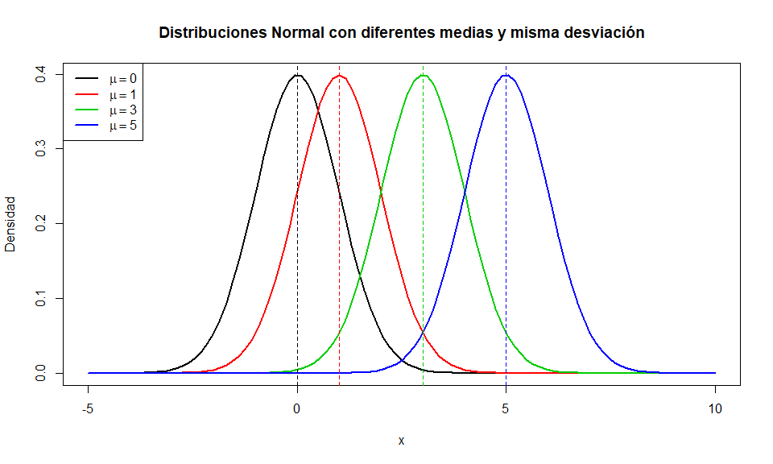

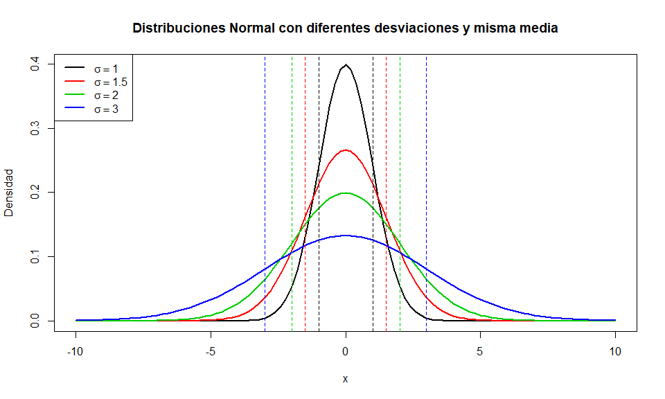

##### Normal Estándar

Cuando $\mu=0$ y $\sigma^2=1$, se obtiene una distribución normal especial, conocida como *Normal Estándar* y usualmente es denotada cola letra $Z$ y se escribe $Z \sim N(0,1)$.

$$P(x_1 < X < x_2)= \int\limits_{x_1}^{x_2} \cfrac{1}{\sqrt{2 \pi} \sigma} \large e^{- \frac{1}{2} \frac{(x-\mu)^2}{\sigma^2}} \small dx$$

Esta probabilidad no puede ser resuelta de manera explícita, además cada vez que se modifique $\mu$ o $\sigma^2$, se debe calcular de nuevo la integral.

###### Normalización

Para evitar este problema, se utiliza el cambio de variable $Z=\cfrac{X-\mu}{\sigma}$, del cual se obtiene que $dz=\cfrac{1}{\sigma}dx$.

$$\begin{aligned}
P(x_1 < X < x_2) &= \int\limits_{z_1}^{z_2} \cfrac{1}{\sqrt{2 \pi}} \mathit{e}^{- \cfrac{z^2}{2}} dz \\
&= P(z_1 < Z < z_2)\\
\end{aligned}$$

donde $z_1=\cfrac{x_1-\mu}{\sigma}$ y $z_2=\cfrac{x_2-\mu}{\sigma}$. Esto indica que cualquier cálculo de probabilidades para una variable aleatoria $N(\mu, \sigma^2)$ puede reducirse al cálculo de probabilidades con una variable aleatoria $N(0,1)$. El proceso de transformar una v.a normal en una normal estándar se conoce como *Estandarización* o *Normalización*.

Para el cálculo de probabilidades con una variable $N(0, 1)$, la c.d.f. estará dada por:

$$\Phi(z)=P(Z \leq z)=\int\limits_{-\infty}^{z} \cfrac{1}{\sqrt{2 \pi}} \large e^{- \frac{z^2}{2}} \small dz$$

De esta manera se tiene que:

$$P(x_1 < X < x_2)=P(z_1 < Z < z_2)=\Phi(z_2)-\Phi(z_1)$$

Los valores de la función $\Phi(z)$ están tabulados en casi todos los textos de estadística.

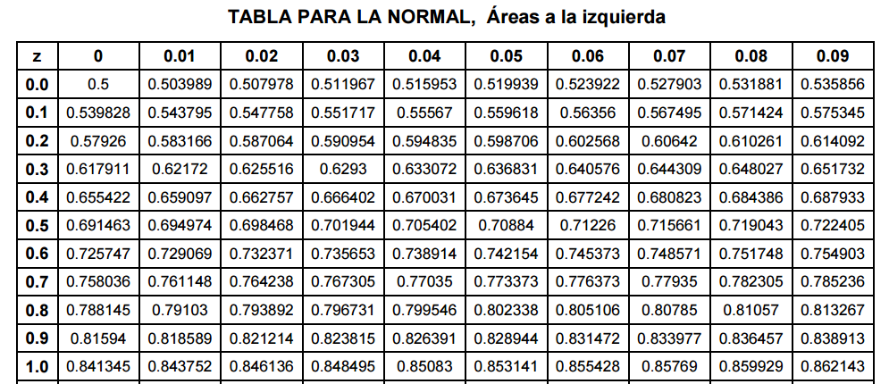

Tabla Distribución Normal

##### Cálculo de probabilidades

Sea $Z$ una v.a tal que $Z \sim N(0,1)$

- $P(Z = z) = 0$
- $P(Z>z)=1-P(Z \leq z)$
- $P(Z<-z)=P(Z>z)$
- $P(-z < Z < 0) = P(0 < Z < z)$
- $P(Z < 0) = P(Z > 0) = \cfrac{1}{2}$
- $P(-z_1 < Z < -z_2)=P(z_2 < Z < z_1)$

##### Características Distribución Normal

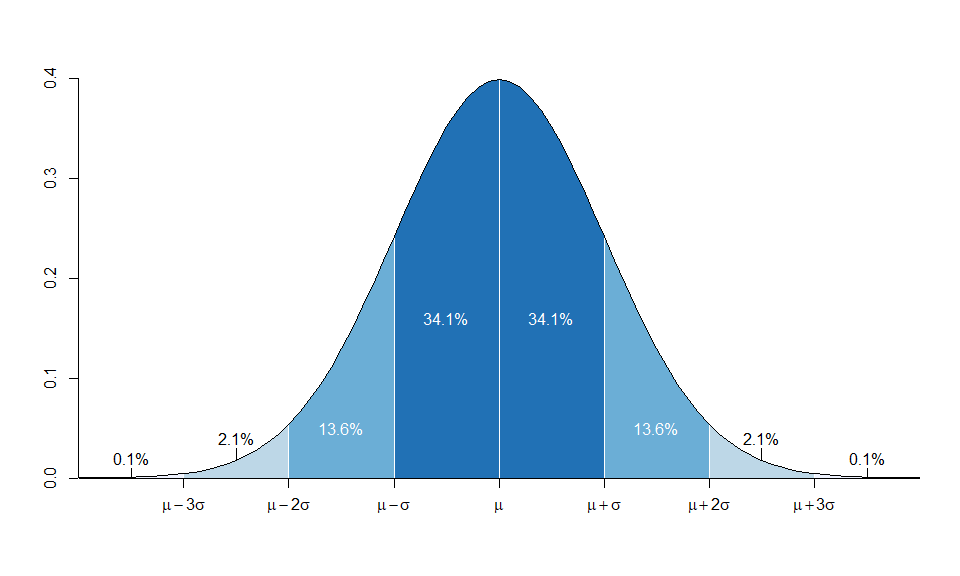

##### Percentiles en una Normal Estándar

Sea $0 < \alpha < 1$ y suponga que $Z \sim N(0,1)$. El valor de $Z$ que deja un área $\alpha$ a la derecha se denota $z_{\alpha}$. Es decir,

$$P(Z>z_{\alpha})=\alpha$$

$z_{\alpha}$ es llamado percentil $100(1-\alpha)\%$ de la distribución de $Z$.

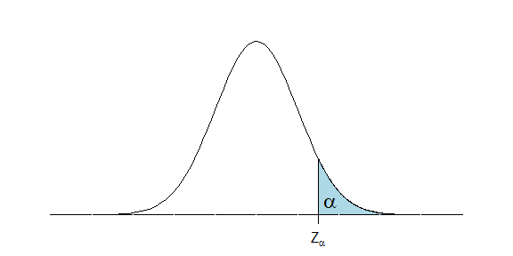

##### Aproximación Normal de la Binomial

Suponga que $X \sim bin(n,p)$. Si $n$ es muy grande, entonces las probabilidades para esta v.a pueden ser aproximadas usando la distribución normal. Esta aproximación implica el uso de un *factor de corrección*, ya que el rango de una variable Binomial es un subconjunto de los enteros no-negativos. Debido a eso, las probabilidades de *valores no enteros* con una distribución Binomial, son calculados al redondear al entero más cercano, según el caso. El factor de correción más usado es $\frac{1}{2}$.

Ahora suponga que $X \sim bin(n, p)$. Si $A_X \in \{0, 1, 2, \ldots , n\}$, y $n_1,n_2 \in A_X$ , entonces se verifica que:

$$P(X=n_1)=P \left(n_1 - \frac{1}{2} < X < n_1 + \frac{1}{2} \right) \quad P(n_1 < X < n_2)=P \left(n_1 - \frac{1}{2} < X < n_2 + \frac{1}{2} \right)$$

Entonces si $n$ es grande, se tiene que:

$$P(X \leq x)=P \left(X<x+\frac{1}{2} \right) \approx P \left(Z \leq \cfrac{x+\frac{1}{2}-np}{\sqrt{np(1-p)}}\right)$$

$$P(X < x)=P \left(X<x-\frac{1}{2} \right) \approx P \left(Z \leq \cfrac{x-\frac{1}{2}-np}{\sqrt{np(1-p)}}\right)$$

En la práctica estas aproximaciones son buenas cuando: $np \geq 10$ y $n(1-p) \geq 10$.

#### Distribución Exponencial

La distribución exponencial tiene una gran utilidad práctica ya que podemos considerarla como un modelo adecuado para la distribución de probabilidad del tiempo de espera entre dos hechos que sigan un proceso de Poisson. De hecho la distribución exponencial puede derivarse de un proceso experimental de Poisson con las mismas características que las que enunciábamos al estudiar la distribución de Poisson, pero tomando como variable aleatoria, en este caso, el tiempo que tarda en producirse un hecho.

Sea $X$ una v.a continua. $X \sim Exp(\lambda)$.

$$f(x) =
\begin{cases}
\lambda \mathit{e}^{-\lambda x} &;\qquad x > 0\\
0 &;\qquad \text{en otro caso}\\
\end{cases}$$

La función generadora de momentos está dada por:

$$M_X(t)=E\left[ e^{tx}\right]=\cfrac{\lambda}{\lambda-t}$$

Así,$E[X]=\frac{1}{\lambda}$ y $\text{Var}[X]=\frac{1}{\lambda^2}$.

La función acumulada está dada por:

$$F(x) =
\begin{cases}
1 - \mathit{e}^{-\lambda x} &;\qquad x \geq 0\\
0 &;\qquad x < 0\\
\end{cases}$$

Por lo general en la distribución exponencial se da el tiempo promedio hasta la ocurrencia de un evento Poisson, es útil igualar el promedio a $E[X]$ para hallar el parámetro $\lambda$ despejando de la ecuación.

[figure not shown]

##### Relación Exponencial–Poisson

Suponga que el número de eventos que ocurren en un intervalo de tiempo de longitud $t$, tiene una distribución de Poisson con parámetro $\alpha$ y que el número de ocurrencias en intervalos que no se translapan son independientes entre sí. Entonces, la distribución del tiempo transcurrido entre la presentación de 2 eventos sucesivos es *exponencial* con parámetro $\lambda=\alpha$.

En otras palabras, suponga que $X \sim pois(\lambda)$ donde $\lambda$ es el número promedio de ocurrencias por unidad de tiempo. Sea $T$ la variable aleatoria que representa el tiempo entre ocurrencias de este proceso Poisson. Entonces $T \sim Exp(\lambda)$. Para mostrar este resultado, se hallará la c.d.f de $T$, es decir, calcular $F(t) = P(T \leq t)$. Por facilidad se calculará primero $P(T > t)$. Para ello se define la variable aleatoria $Y$: número de ocurrencias en un intervalo de longitud $t$. Entonces $Y \sim pois(\lambda^*)$. En este caso $\lambda^* = \lambda t$.

Así, $Y \sim pois(\lambda t)$. De esta manera:

$$F(t)=1-P(T>t)=1-P(Y=0)=1-\mathit{e}^{-\lambda t}$$

La cual corresponde a la acumulada de una exponencial con parámetro $\lambda$.

##### Propiedad de carencia de memoria

Suponga que $X$ es una variable aleatoria tal que $X \sim Exp(\lambda)$. Sean $t_1$ y $t_2$ reales positivos. Entonces:

$$P(X < t_1+ t_2 |X \geq t_1) = P (X < t_2)$$

#### Distribución Log-Normal

Una variable aleatoria $X$, no negativa, tiene una p.d.f Lognormal si $Y = ln(X)$ es una v.a con p.d.f normal. Haciendo $\mu = E[Y]$ y $\sigma^2 = Var[Y]$, la p.d.f de $X$ es de la forma

$$f(x)=\cfrac{1}{x\sigma \sqrt{2 \pi}} \large e^{- \frac{1}{2} \frac{(\text{ln}(x)-\mu)^2}{\sigma^2}}; \quad \small \forall_x >0$$

$\mu$ y $\sigma^2$ **NO** son la media y varianza de $X$. Son la media y varianza de $\text{ln}(X)$.

$$E[X]=\mathit{e}^{\mu+\frac{\sigma^2}{2}} \quad\quad Var[X]=\mathit{e}^{2\mu+\sigma^2}\Big(\mathit{e}^{\sigma^2}-1\Big)$$

El cálculo de probabilidades con una p.d.f Lognormal es algo complicado. Pero debido al hecho de que *el logaritmo natural de un v.a Lognormal es una v.a normal*, podemos usar las tablas para una normal estándar para calcular dichas probabilidades. Como $\text{ln}(X)$ es una función estrictamente creciente, entonces:

$$\begin{aligned}
P(X \leq a) &= P\left(\text{ln}[X] \leq \text{ln}[a]\right)=P\left(\cfrac{\text{ln}[X]-\mu}{\sigma} \leq \cfrac{\text{ln}[a]-\mu}{\sigma}\right) \\\\
&= P\left(Z \leq \cfrac{\text{ln}[a]-\mu}{\sigma}\right)= \Phi\left(\cfrac{\text{ln}[X]-\mu}{\sigma}\right)
\end{aligned}$$

Así, la f.d.a de $X$ es de la forma:

$$F(X)=P(X \leq x)=\Phi\left(\cfrac{\text{ln}[X]-\mu}{\sigma}\right); \quad \forall_x >0$$

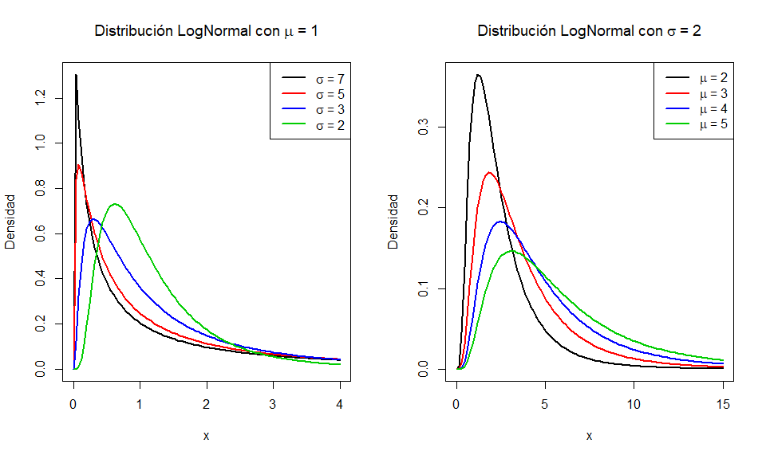

#### Distribución Gamma

En distintos ámbitos interesa modela fenomenos que involucren conteos y tiempos al mismo tiempo. Hasta ahora hemos visto una aproximación con las distribuciones Exponencial y Poisson, siempre y cuando los parámetros sean proporcionales. ¿Qué pasaría si esto no se cumple?

Conocer el comportamiento de muchos fenómenos que relacionen el tiempo supervivencia (vida util) entre un número de ocurrencias de un evento, se de gran interés. En este caso es muy importante conocer una distribución que nos permita conocer las probabilidades, un valor esperado y una variabilidad de la ocrurrencia de el evento de interés y para ello vamos a considerar la siguiente distribución.

Esta distribución es usualmente usada en el análisis de superivencia, en confiabilidad y demás áreas que tienen un enfoque relacionado en observar el tiempo de falla o de vida de una persona, duración de productos industriales, tiempo que transcurre un número de personas en una fila.

Recuerde que la función Gamma está dada por:

$$\Gamma(\alpha)=\int_{0}^{\infty}x^{\alpha-1}e^{-x}dx \qquad x>0,\quad a>0$$

Sea $X$ una variable aletoria continua tal que $X\sim Gamma(\alpha,\beta)$. Así la f.d.p está dada por:

$$f_{(\alpha,\beta)}(x)= \frac{1}{\Gamma(\alpha)\beta^{\alpha}}x^{\alpha-1}e^{-x/\beta} \quad \alpha,\beta,x>0$$

La probabilidad de llegar hasta un valor de x $P(X<x)$ es decir, la f.d.a es:

$$P(X<x)=\int_{0}^{x}\frac{1}{\Gamma(\alpha)\beta^{\alpha}}t^{\alpha-1}e^{-t/\beta}dt \quad \alpha,\beta,t>0$$

$$M_{x}(t)=(1-\beta t)^{-\alpha}, \quad t< \frac{1}{\beta}$$

Entonces $E[x]=\alpha \beta$ y $\text{Var}[X]=\alpha\beta^{2}$.

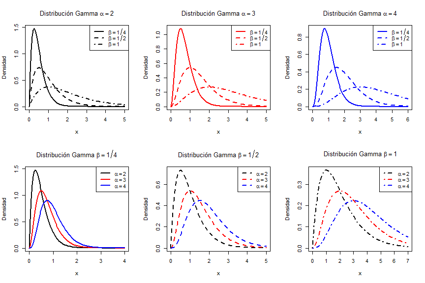

```r
par(mfrow=c(2,3))
curve(dgamma(x,shape=2,scale=1/4),xlim=c(0,5),lwd=2,ylab='Densidad',
     main=expression("Distribución Gamma "*alpha==2))
curve(dgamma(x,shape = 2,scale = 1/2),lty=2,lwd=2,add=T)
curve(dgamma(x,shape = 2,scale = 1),lty=4,lwd=2,add=T)
legend('topright',col=1,lty=c(1,2,4),lwd=2,legend=c(expression(beta==1/4),
                                                    expression(beta==1/2),
                                                    expression(beta==1)))

curve(dgamma(x,shape=3,scale=1/4),xlim=c(0,5),col=2,lwd=2,ylab='Densidad',
     main=expression("Distribución Gamma "*alpha==3))
curve(dgamma(x,shape = 3,scale = 1/2),lty=2,col=2,lwd=2,add=T)
curve(dgamma(x,shape = 3,scale = 1),lty=4,col=2,lwd=2,add=T)
legend('topright',col=2,lty=c(1,2,4),lwd=2,legend=c(expression(beta==1/4),
                                                    expression(beta==1/2),
                                                    expression(beta==1)))

curve(dgamma(x,shape = 4,scale = 1/4),xlim=c(0,6),col=4,lwd=2,ylab='Densidad',
     main=expression("Distribución Gamma "*alpha==4))
curve(dgamma(x,shape = 4,scale = 1/2),lty=2,col=4,lwd=2,add=T)
curve(dgamma(x,shape = 4,scale = 1),lty=4,col=4,lwd=2,add=T)
legend('topright',col=4,lty=c(1,2,4),lwd=2,legend=c(expression(beta==1/4),
                                                    expression(beta==1/2),
                                                    expression(beta==1)))

curve(dgamma(x,shape = 2,scale = 1/4),xlim=c(0,4),lwd=2,ylab='Densidad',
     main=expression("Distribución Gamma "*beta==1/4))
curve(dgamma(x,shape = 3,scale = 1/4),col=2,lwd=2,add=T)
curve(dgamma(x,shape = 4,scale = 1/4),col=4,lwd=2,add=T)
legend('topright',col=c(1,2,4),lty=1,lwd=2,legend=c(expression(alpha==2),
                                                    expression(alpha==3),
                                                    expression(alpha==4)))

curve(dgamma(x,shape = 2,scale = 1/2),xlim=c(0,5),lwd=2,lty=2,ylab='Densidad',
     main=expression("Distribución Gamma "*beta==1/2))
curve(dgamma(x,shape = 3,scale = 1/2),col=2,lwd=2,lty=2,add=T)
curve(dgamma(x,shape = 4,scale = 1/2),col=4,lwd=2,lty=2,add=T)
legend('topright',col=c(1,2,4),lty=2,lwd=2,legend=c(expression(alpha==2),
                                                    expression(alpha==3),
                                                    expression(alpha==4)))

curve(dgamma(x,shape = 2,scale = 1),xlim=c(0,7),lwd=2,lty=4,ylab='Densidad',
     main=expression("Distribución Gamma "*beta==1))
curve(dgamma(x,shape = 3,scale = 1),col=2,lwd=2,lty=4,add=T)
curve(dgamma(x,shape = 4,scale = 1),col=4,lwd=2,lty=4,add=T)
legend('topright',col=c(1,2,4),lty=4,lwd=2,legend=c(expression(alpha==2),
                                                    expression(alpha==3),
                                                    expression(alpha==4)))
```

#### Distribución Beta

En muchos casos no es posble encontrar proporciones constantes en un fenómeno como el caso de una distribución uniforme, sin embargo hay una distribución que nos permite darle forma y controlar ciertos parámetros para obtener una f.d.p que es “conocida” y tiene una forma matematicamente cerrada, a esta distribución se le conoce como la distribución Beta.

Hoy en día la distribución *beta* ha tomado mucha importancia en el campo de la estadística bayesiana tomándose como distribución a priori para modelar proporciones por ejemplo de una distribución binomial, realizar estimaciones de una prevalencia o para modelar índices de riesgos.

Sea $X$ una v.a continua tal que $X\sim Beta(\alpha,\beta)$ con dominio solo para $x\in[0,1]$

Cuya f.d.p viene dada por:

$$f_{(\alpha,\beta)}(x)= \frac{\Gamma(\alpha+\beta)}{\Gamma(\alpha)\beta^{\alpha}}x^{\alpha-1}(1-x)^{\beta-1} \quad \alpha,\beta>0; \quad 0<x<1$$

La probabilidad de estar entre $a$ y $b$ con $0<a<b<1$ será:

$P(a<X<b)= \int_{a}^{b} \frac{\Gamma(\alpha+\beta)}{\Gamma(\alpha)\beta^{\alpha}}x^{\alpha-1}(1-x)^{\beta-1}dt \quad \alpha,\beta>0; \quad 0<x<1$

La probailidad de llegar hasta un valor x $P(X<x)$ la f.d.a se calcula como:

$P(X<x)= \int_{0}^{x} \frac{\Gamma(\alpha+\beta)}{\Gamma(\alpha)\beta^{\alpha}}t^{\alpha-1}(1-t)^{\beta-1}dt \quad \alpha,\beta>0; \quad 0<t<1$

$$M_{x}(t)=1+\sum_{k=1}^{\infty}\left(\prod_{r=0}^{k-1}\frac{\alpha+r}{\alpha+\beta+r}\right)\frac{t^{k}}{k!}$$

Entonces $E[X]=\frac{\alpha}{\alpha+\beta}$ y $\text{Var}[X]=\frac{\alpha \beta}{(\alpha+\beta)^{2}(\alpha+\beta+1)}$.

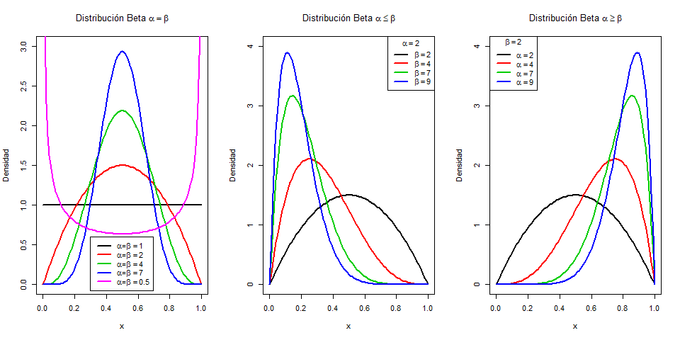

```r
par(mfrow=c(1,3))
curve(dbeta(x,1,1),xlim=c(0,1),ylim=c(0,3),ylab='Densidad',lwd=2,
      main=expression('Distribución Beta '*alpha==beta))
curve(dbeta(x,2,2),col=2,lwd=2,add=T)
curve(dbeta(x,4,4),col=3,lwd=2,add=T)
curve(dbeta(x,7,7),col=4,lwd=2,add=T)
curve(dbeta(x,0.5,0.5),col=6,lwd=2,add=T)
legend(x=0.3,y=0.6,lty=1,col=c(1:4,6),lwd=2,
       legend=c(expression(alpha*'='*beta==1),expression(alpha*'='*beta==2),
                expression(alpha*'='*beta==4),expression(alpha*'='*beta==7),
                expression(alpha*'='*beta==0.5)))

curve(dbeta(x,2,2),xlim=c(0,1),ylim=c(0,4),ylab='Densidad',lwd=2,
      main=expression('Distribución Beta '*alpha<=beta))
curve(dbeta(x,2,4),col=2,lwd=2,add=T)
curve(dbeta(x,2,7),col=3,lwd=2,add=T)
curve(dbeta(x,2,9),col=4,lwd=2,add=T)
legend('toprigh',lty=1,col=1:4,lwd=2,title=expression(alpha==2),
       legend=c(expression(beta==2),expression(beta==4),
                expression(beta==7),expression(beta==9)))

curve(dbeta(x,2,2),xlim=c(0,1),ylim=c(0,4),ylab='Densidad',lwd=2,
      main=expression('Distribución Beta '*alpha>=beta))
curve(dbeta(x,4,2),col=2,lwd=2,add=T)
curve(dbeta(x,7,2),col=3,lwd=2,add=T)
curve(dbeta(x,9,2),col=4,lwd=2,add=T)
legend('topleft',lty=1,col=1:4,lwd=2,title=expression(beta==2),
       legend=c(expression(alpha==2),expression(alpha==4),
                expression(alpha==7),expression(alpha==9)))
```

#### Distribución $\chi^2$

La distribución de *Pearson*, llamada también *ji cuadrada(o)* o *chi cuadrado(a)* ($\chi^2$), es una distribución de probabilidad continua con un parámetro $r$ que representa los grados de libertad de la variable aleatoria.

$$f(x)=
\begin{cases}\displaystyle
\frac{1}{2^{r/2}\Gamma(r/2)}\,x^{(r/2) - 1} e^{-x/2}&\text{para }x>0,\\
0&\text{en otro caso}
\end{cases}$$

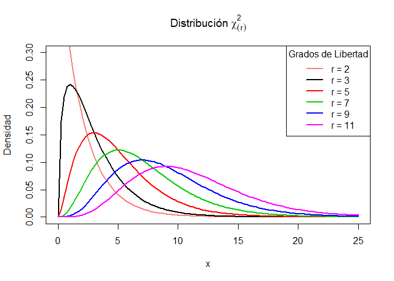

```r
curve(dchisq(x,2),lwd=2,ylab='Densidad',xlim=c(0,25),ylim=c(0,0.3),col='salmon',
     main = expression('Distribución '*chi[(r)]^2))
curve(dchisq(x,3),col=1,lwd=2,add=T)
curve(dchisq(x,5),col=2,lwd=2,add=T)
curve(dchisq(x,7),col=3,lwd=2,add=T)
curve(dchisq(x,9),col=4,lwd=2,add=T)
curve(dchisq(x,11),col=6,lwd=2,add=T)
legend('topright',legend=c('r = 2','r = 3','r = 5','r = 7','r = 9','r = 11'),
       col=c('salmon',1:4,6),lty=1,lwd=2,title='Grados de Libertad')
```

#### Distribución *t-student*

La distribución *t-de Student* es una distribución de probabilidad que surge del problema de estimar la media de una población normalmente distribuida cuando el tamaño de la muestra es pequeño. Su *f.d.p* está dada por:

$$f(x) = \frac{\Gamma\left(\dfrac{\nu + 1}{2}\right)}{\Gamma\left(\dfrac{\nu}{2}\right)\sqrt{\pi\nu}\sigma} \left[1+\frac{1}{\nu}\left(\frac{x-\mu}{\sigma}\right)^2\right]^{-\tfrac{\nu+1}{2}}$$

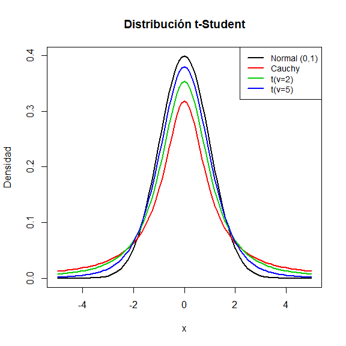

```r
curve(dnorm(x),xlim=c(-5,5),main='Distribución t-Student',ylab='Densidad',lwd=2)
curve(dt(x,df = 1),col=2,add=T,lwd=2)
curve(dt(x,df = 2),col=3,add=T,lwd=2)
curve(dt(x,df = 5),col=4,add=T,lwd=2)

legend('toprigh',lty=1,col=1:4,lwd=2,cex=0.9,
       legend=c('Normal (0,1)','Cauchy','t(v=2)','t(v=5)'))
```

En esta gráfica podemos apreciar la realción que existe entre las distribuciones *Cauchy*, *t-de Student* y la *Normal Estandarizada*. Se observa que la distribución *t-de Student* con $v = 1$ grado de libertad es una *distribución Cauchy* la cual es la más achatada y presenta las colas mas pesadas en comparación las demás distribuciones presentes en la gráfica. Además se puede evidenciar que a medida que aumentan los grados de libertad en la *distribución t*, ésta tiende a la *Normal*.

#### Distribución Normal Bivariada

Una *distribución normal multivariante*, también llamada distribución gaussiana multivariante, es una generalización de la distribución normal unidimensional a dimensiones superiores.

Para el caso bivariado el vector aleatorio $(X,Y)$, que toma todos lo valores en el plano euclidiano, tiene la siguiente función de distribución de probabilidad:

$$f(x,y)=\frac{1}{2 \pi \sigma_x \sigma_y \sqrt{1-\rho^2}}
\exp
\left\{
-\frac{1}{2 (1-\rho^2)}
\left[
\left(\frac{x-\mu_x}{\sigma_x} \right)^2 -
2 \rho \frac{(x-\mu_x)(y-\mu_y)}{\sigma_x \sigma_y}+
\left(\frac{y-\mu_y}{\sigma_y} \right)^2
\right]
\right\}$$

##### Distribución Normal Bivariada $\mu=[0,0]$ $\sigma=[5,5]$ $cov=0$ $\rho=0$

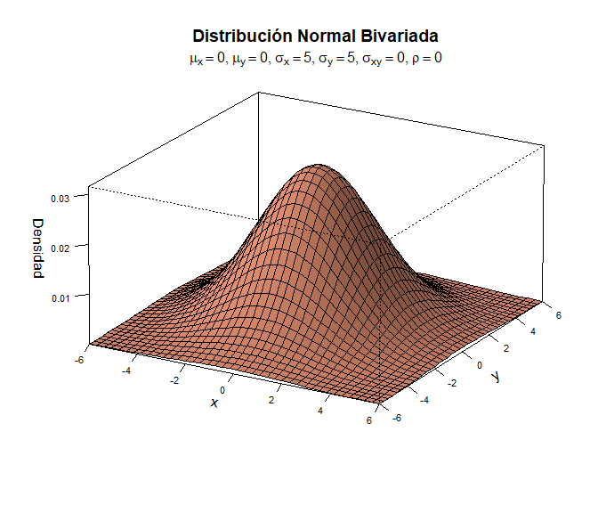

```r
x<-seq(-6,6,length=40);y<-x

# Función Normal Bivariada
f<-function(x,y,mu=c(0,0),s=c(1,0,1))
{
  mu1<-mu[1];mu2<-mu[2]
  s11<-s[1];s12<-s[2];s22<-s[3];rho<-s12/(s11*s22)
  term1<-1/(2*pi*sqrt(s11*s22*(1-rho^2)))
  term2<--1/(2*(1-rho^2))
  term3<-(x-mu1)^2/s11
  term4<-(y-mu2)^2/s22
  term5<--2*rho*((x-mu1)*(y-mu2))/(sqrt(s11)*sqrt(s22))
  term1*exp(term2*(term3+term4-term5))
}

z<-outer(x,y,f,s=c(5,0,5)) # matriz de densidades

persp(x, y, z,col="lightsalmon",theta=30, phi=20,r=50,d=0.1,expand=0.5,ltheta=90,
      main="Distribución Normal Bivariada",lphi=180,shade=0.3,ticktype="detailed",
      nticks=5,cex.axis=0.7,zlab = 'Densidad')
mtext(expression(list(mu[x]==0,mu[y]==0,sigma[x]==5,sigma[y]==5,
                      sigma[xy]==0,rho==0)), side=3)
```

En este gráfico se puede observar que la distribucíon normal bivariada cuando la correlación entre las variables $x$ y $Y$ es cero $(\rho=0)$, la superficie dibuja la clásica campana de gauss, en la posición marcada por el vector de medias de la distribución.